# Data Analysis 3 - Assignment 2 - Technical Report

Perice Prediction for Arbnb Apartments in Melbourne, Australia

Ali Sial

2/10/2022

## Introduction

This documents aims to build price prediction models, which will help a company that operates **small and mid-size apartments hosting 2-6 guests in Melbourne, Australia**. The predicted prices produced as a result of the analysis explained below will form the base for the company to price their new apartments that are going on market soon. The data used for prediction is the **Airbnb prices in Melbourne,Australia.** obtained from **[Inside Airbnb](http://insideairbnb.com/get-the-data.html)**. The prediction models were built on various predictors, such as the type of property and people it accommodates, where it’s located or what unique features it includes, also incorporating the information about the host and reviews. The prediction algorithms used for this analysis are OLS, Cart, Random forest (with and without tuning) and GBM. I also used LASSO, but as a predictor to extract important variables to be used in the models. After conducting the analysis, the model choose for final prediction based on its performance is **Random Forest with Auto Tuning**. The entirety of this project, including codes and data, is available on my **[GitHub](https://github.com/alisial94/DA3_Airbnb_Price_Prediction)** (please click to open the link).

## The Data and Initial Clean

The raw data is available on Inside Airbnb, for convenience, It has also been uploaded to my GitHub and can be directly retrieved from there (raw data can be found **[here](https://github.com/alisial94/DA3_Airbnb_Price_Prediction/blob/main/Data/raw/raw_melb_listing.csv)**). After studying the data in detail, I realised that even though there is no question about its quality, but still the data required a lot of cleaning and feature engineering before it can be used for modeling. The data is of cross-sectional nature containing information related Airbnb listings in Melbourne, Australia which was scrapped between January 08, 2022 and January 09, 2022. Since the intention of this exercise is to predict property prices, thus it our target variable which is stated in local currency i.e. Australian Dollar. Raw data includes 17409 observations (unique listings) and 74 variables. The codes for changes made to data explained are available on my **[GitHub](https://github.com/alisial94/DA3_Airbnb_Price_Prediction/blob/main/Codes/1_data_cleaning.R)** (please click to open the link).

To begin initial clean, I identified 4 columns with more than 50% missing values. After investigating further, the four columns contained only NA values, thus I decided to add them to the pool of variables that I will drop initially. Next I individually analysed the variables to check if they would be useful for the analysis and listed additional 27 variables out of the 74 that i will drop. These variables were either of a descriptive nature such as description of the place or host, or there were variables in the data that explained information more precisely than the ones being dropped.

For the remaining 43 variables, I checked the values contained in them to identify if any of the columns contained signs such as dollar sign in price or percentage sign in host response and acceptance rate. Few adjustments were also made to the variables by replacing zero values with NAs, in case it was added as a result of removing these signs. Additionally, 224 observations with NAs in the price column were also dropped.

The data also has column for amenities, which is a string that encompasses all the amenities available at the property. The column was split in to 1468 amenities columns after which they had to be further reclassified and cleaned in to meaningful binary amenities. This task was carried out using my own understanding of how these amenities could be pooled together. Upon creating these pooled binary categories only 155 amenities column remained. These were further reduced to 79 total amenities as I decided to only include binaries which had either more than 1% or less than 99% ratio of the value ‘1’ in them. The reason for doing this was to ensure that only amenities that had some variation were included in the data. The initial adjustment phase concludes here with a data containing **17185 observations and 121 variables** which will be further explored (please click **[here](https://github.com/alisial94/DA3_Airbnb_Price_Prediction/blob/main/Data/clean/melborne_initial_clean.csv)** to retrieve this data directly).

## Data Cleaning, Mungging & Selection

This phase explains how I filtered the data based on the criteria and boundaries we had initially established for this analysis. The approach I used in exploring the data was by dividing variables into factors, numeric, percentages/ratios and dummy/binary. To do this I decided to add ’f” (for factor),“n (for numeric)”,“p” (for percentages) and “d” (for dummy)to name of variables so its easy to identify them. Codes for this phase have and also the next phase explained in this document have been uploaded as a separate R file to my **[GitHub](https://github.com/alisial94/DA3_Airbnb_Price_Prediction/blob/main/Codes/2_prepare_data.R)** (please click to review it)

As stated above the company we are predicting the prices for is only interested in apartments or housing units accommodating 2 to 6 people, therefore, I first filtered the data based on these two requirements. For property type, I selected four categories that are Condo, Serviced Apartments, Loft and Home/Apartment and stored these property types as factors. Upon applying these two major filters the observations in our data set dropped to **822**.

After this, I looked at the different room types that these filtered properties had and it turns out that there is only one category in that column which is “Entire Home/Apt”. As there is no variation in room type I decided to not use that variable in our prediction models. At this stage the variables that were included in the list of factor variables other than property type are neighborhood cleansed and host response time.

As far as the numerical or percentage variables are concerned, I begun by converting are target variable price which is recorded in the local currency to US Dollar. For this I used the exchange rate provided by Google at that day and cross validated it with the few other currency exchange banks/companies. Number of bathrooms that are present at each property was recorded as bathroom_text which was also cleaned and stored as a numerical variable. There are two percentage variables host response rate and host acceptance rate. For simplicity purposes I also included them to the list of numerical variables for now, but later on in my analysis changed renamed them as percentage variables. Similarly, I explored other numerical variables as well to see if any adjustments were required and stored them as numerical.

The same process was used for the binary variables which mainly included all the amenities that we had created in the previous phase. I also checked other variables that could be used as binary and based on my own understanding about the importance of variables with regards to question a hand, I only included three other dummy variables which are; whether the host is a super host, is host’s identity verified and if the property can be booked instantly. When I exploring the dummy variables, I realised that a variables that records whether the host has a profile picture or not had only 3 observations with hosts not having a profile picture. Therefore, I felt it was correct to not use this variable due to lack of variation and decided to drop these observations.

This phase concluded by creating the a **[CSV file](https://github.com/alisial94/DA3_Airbnb_Price_Prediction/blob/main/Data/clean/melborne_listing_data_final_variables.csv)** (please click to directly download it from my git) for clean data with **819 observations and 104 variables**, not all of them are the one we will use in our analysis in fact they are included just for informational purpose.

## Investigating Variables - Ajusting Functional Forms & Feature Engineering

The variable examined was the target variable price in USD. Even though I had already dropped the observation with missing price, just to be sure reapplied the filter. The price data, as always, had a right long tail and I felt it was wise to drop few large values. Therefor I filtered the data to observations that had less than USD 400 price. Below provided is the histogram for this price distribution which is still slight slightly right skewed. I understand that in this case taking a log normal price distribution would have been a better approach, but for simplicity of interpretation on a later stage, thus, I decided to continue with price as is. Log normal price distribution is also added below just for your understanding. To understand the relationship between price and two key variables, have added two box plots as well.

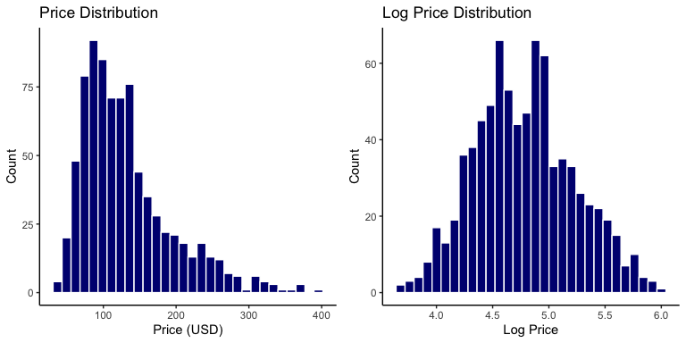

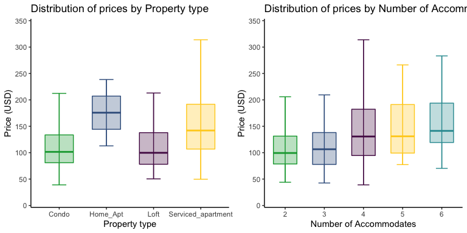

Next I looked at other numerical variables we have in the data set to check again for missing values, feature engineering, pooling/clubbing and reclassification or categorisation. I imputed the variables where there were missing values and alongside I even added a flag variable where the missing values were more than 5% (for example for number of beds only had 7 missing values, thus no flag added). Adjustments made to each variable is explained below followed by distribution graphs for few key variables to show how they looked before they were transformed.

- *Number of people the property accommodates:* had no missing values and I decided to use it as is.
- *Number of bathrooms:* had five unique values which are 1, 1.5, 2, 2.5 and 3 and were pooled in three categories of 1,2 and 3 bathrooms
- *Number of bedrooms:* there are few missing values in this variable and imputation I made for it was based on the assumption that 1 bedroom accommodates 2. Before imputing these values I even added a flag variable for it. Furthermore number of bathrooms were pooled in 3 more meaningful categories (1,2 & 3).
- *Number of beds:* I applied the same principal as stated above by imputing missing values with 1 bed for 2 persons accommodation and pool them into three categories.
- *Review Score Rating:* added flag for the missing values and imputed them with the median value for of the variable. As you can see from the graph below that majority of the values before imputation are between the range 4-5, thus, the variable was factorised into two categories 0-4.5 and 4.5-5.
- *Number of Reviews:* The variable had few extremely large values. I didn’t drop them because I planned to pool them into three categories none, 1-51 and 51+. Furthermore, I as you can see from the graph provided below the distribution is right skewed so to account for that I also added a log normal distribution.
- *Minimum nights:* there was one observation that had an extremely large value (865 days), which could have been an error since all other recorded values were below 365 days. Therefore, this one observation was dropped from the data set. The distribution provided below shows a right long tail, but even after adding a log normal distribution not much changed so I kept the original variable values as is, but I further pooled them into four categories 1, 2, 3 and 3+ nights.
- *Days since first review:* for this variable a log normal distribution was added and three pooled categories were created <500, 500-1000 and 1000+.

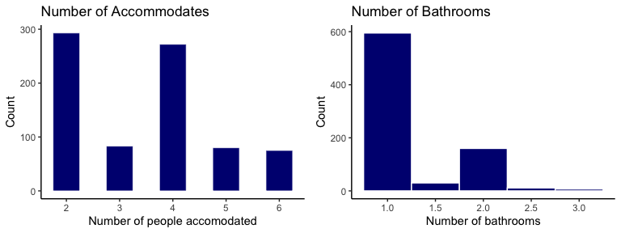

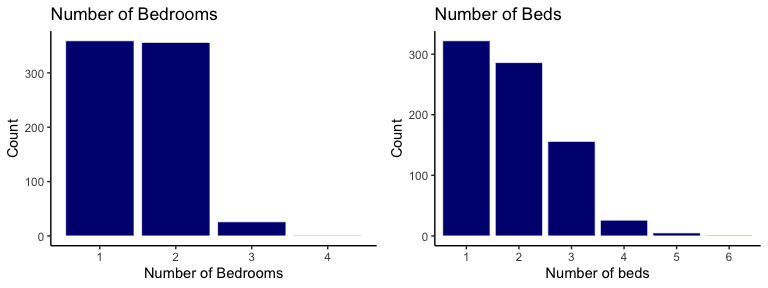

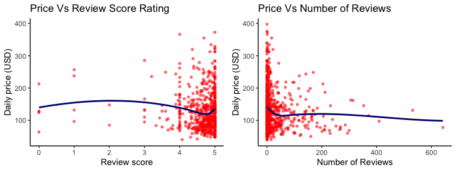

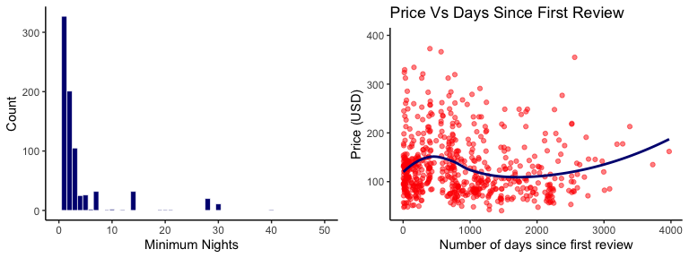

A variable named “Calculated Count of Host Listings” was also in the dataset. After investigating this variable in detail, even though based on domain knowledge it is a good indicator for price, but since it also possible that different number of the host listing are also present in our data set thus it was inflating the number of listing total. Which means reliability of this variable is slightly compromised, therefore, I have decided to drop it from analysis. Other variables where there were missing values, either they were imputed with median or ‘missing’ and flags were also added. I also renamed and further grouped amenities that I felt were not properly pooled. This concludes are entire cleaning and feature engineering section and a CSV for this stage has also been created which can be retrieved from my **[GitHub](https://github.com/alisial94/DA3_Airbnb_Price_Prediction/blob/main/Data/clean/melborne_prepared.csv)** (please click to open the link). The final observations and variables after this stage are **802 and 119** respectively.

## Validation & Holdout

The data being used for this price prediction had shrunk more than I expected due the filters and other parameters applied, therefor, I decided to separate the remaining 802 observations in to 80% working set on which all the training will be performed and 20% holdout set. The idea behind doing this was to maximise the overall performance models being run on the data set that I am working with and also to ensure the final accuracy of out of sample. Furthermore, The OLS models were trained using 5-fold cross-validation in order to ensure that least over-fitting coefficients are used. The final results for all the models were compared based on both, the RMSE and BIC are used.

## Final Explanatory Variables and Interaction Terms

The explanatory variables which I used in the models after cleaning were mainly selected based on domain knowledge and by examining their relationship with price (using Lowess). The variables are:

- *Factor variables*: Type of property, neighborhood including flag and factorised variable of size variables (such as number of accommodates/bedrooms/beds/baths/minimum nights).
- *Reviews variables*: Review score rating, total number of reviews, total reviews for the property every month, number of days since first review (etc.) including flags.
- *Host variables*: Dummies created for host verification, host being a super host or not, host response and acceptance rates (etc.) including flags.
- *Dummy Amenities*: this included all the binary variables created for amenities being offered at the property.

## OLS Predictive Models

As mentioned above, based on the predictors highlighted by LASSO, I begin building models for the OLS methodology. Below you can see the OLS Models:

- M1 - 1 ~ number of accommodates
- M2 - 7 = M1 + property type + neighborhoods + number of beds + number of bathrooms + number of bedrooms + flag for number of bedrooms + minimum nights
- M3 - 45 = M2 + host related variables + review related variables + amenities
- M4 - 82 = the most complex model (based on this the LASSO model was run to select variables to be used in first 3 models)

OLS Regression

| Model | Coefficients | R_squared | BIC | Training_RMSE | Test_RMSE |
| --- | --- | --- | --- | --- | --- |
| M1 | 2 | 0.0924999 | 7090.252 | 60.43669 | 60.35611 |
| M2 | 33 | 0.4092751 | 7015.397 | 48.76071 | 52.10255 |
| M3 | 73 | 0.5578302 | 7088.248 | 42.18634 | 48.58235 |
| M4 | 161 | 1.0000000 | -28085.262 | 0.00000 | 56.13839 |
| LASSO | 97 | 0.4023064 | NA | NA | 49.62587 |

## Random Forest

After OLS, I decide to run the Random Forest prediction modeling which results in creation of many imperfect regression trees and the results of these trees are then aggregated to produce the final prediction, which indeed is better than a single model. Random Forest is designed on a similar methodology as the OLS and uses 5-fold cross validation to predict the final values for our holdout set. Predictors provided for the random forest are the same we used to OLS models based on LASSO. For this study, I took inspiration from choices made in Bekes & Kezdi’s RF tuning parameter which is 3-by-3 grid for defining the mtry tuning parameter. The stopping rule I used for the minimum number of observations in terminal nodes is 5,10,15. As far as the number of variables is concerned I used a range from 8-12 variables and the maximum number of trees was set at 500.

RF with Tuning

| nodes | 8 | 10 | 12 |
| --- | --- | --- | --- |
| 5 | 49.37479 | 48.54128 | 48.05859 |
| 10 | 49.78114 | 49.09731 | 48.64446 |
| 15 | 50.12784 | 49.77138 | 49.16731 |

RF Auto Tuning

| Rsquared | 2 | 77 | 152 |
| --- | --- | --- | --- |
| 0.2669665 | 57.38320 | NA | NA |
| 0.2946140 | 56.80267 | NA | NA |
| 0.4043016 | NA | NA | 49.06865 |
| 0.4045088 | NA | NA | 49.13113 |
| 0.4130901 | NA | 48.71002 | NA |
| 0.4232918 | NA | 48.34908 | NA |

## CART and GBM

To further validate my previous models, I used the CART algorithm to build a regression tree on the levels of all variables. I used CART model with pruning to investigate how my prediction looks based on the Test RMSE value. The lowest test RMSE was 54.34 which indeed is higher than both RF and OLS. As you can see from the Cart Tree below, the higher value of RMSE is understandable because not many branches of the tree were constructed, thus the data was being over-fitted. For GBM, the parameters defined were as such, complexity of the tree was set a 5 with 250 maximum number of iteration i.e. trees. Shrinkage with is the learning rate or how quickly the algorithm adapts based on data was set 0.1 and the minimum number of training set samples in a node to commence splitting was 20. The RMSE value resulted after running GBM was closer to lowest Test RMSE so far (GBM RMSE = 48.96.2), but since Random Forest with Tuning produced the lowest RMSE it would be our preferred as compared to the rest.

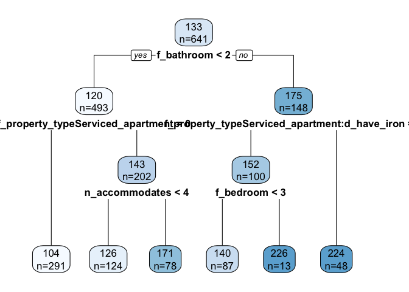

## Comparing Models

Based on the analysis explained above lets evaluate the results. The table below shows a comparison of all the Models that we used in this study. Random Forest, especially the one with tuning parameters performed the best in train data. GBM was indeed close, maybe with some other parameters it could have out performed the random forest. CART’s performance was the worst as it has the highest RMSE in both work samples but it produced better results in holdout data. Random Forest with auto tuning was the winner in the holdout sample. I believe the values obtained after the analysis had alot to do with the limited data we were left with as a result of parameters/filters set for the scope of this study.

Horse Race of Models CV RSME

|  | CV Rsquared | CV RMSE | Holdout RMSE |
| --- | --- | --- | --- |
| OLS | 0.3408111 | 52.10255 | 53.76429 |
| CART | 0.2849101 | 54.34200 | 49.20637 |
| Random forest 1: Tuning provided | 0.4541799 | 48.05859 | 40.60734 |
| Random forest 2: Auto Tuning | 0.4232918 | 48.34908 | 39.57099 |
| GBM | 0.4131496 | 48.96713 | 44.08140 |

## Variable Importnace

The purpose of variable importance is to identify the predictors that impact the target variable the most. In this study we used the best performing model which is Random Forest with tuning to identify these variables. Number of bedrooms, number of people the property accommodates and number of bathrooms were the top performing variables. Below you can also see the graph highlighting the top 10 variables. Moreover, the second graph show the grouped explanatory variables importance graph which clearly shows that overall amenities and property type tend to be the most impact on the price.

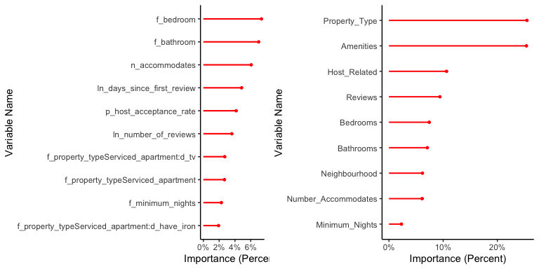

## Partial Dependencies:

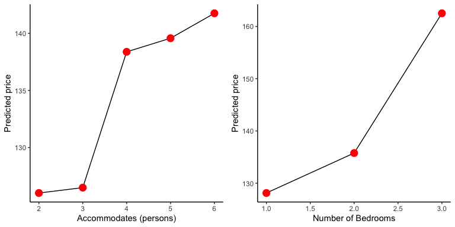

## Sub Sample

To further investigate the performance of choose model (RF), I ran sub sample on 4 key variables as shown in the table below. For apartment size the prediction error is lower was small size apartments, thus we can say that our model predicted better prices for small apartments (predicted price = USD 109.97).As far as the Borough (neighborhood) is concerned, the best prediction was for Stonnington even though the most observations in our data were Melbourne. The third variable used is number of beds in the apartment, the best prediction was made for apartments having only 1 bed. Serviced apartments tends to have the best prediction based on our results for the type of property. The predicted price is also the highest among the categories for type of property, therefore it would be a good idea to invest in that type of apartment.

Predictions

| Var.1 | RMSE | Mean.price | RMSE.price |
| --- | --- | --- | --- |
| Apartment size | NA | NA | NA |
| large apt | 47.20714 | 147.4901 | 0.3200698 |
| small apt | 28.39056 | 109.9743 | 0.2581564 |
| Borough | NA | NA | NA |
| Melbourne | 45.22346 | 137.2267 | 0.3295528 |
| Port Phillip | 35.18057 | 117.9389 | 0.2982949 |
| Stonnington | 30.73779 | 114.4047 | 0.2686760 |
| Yarra | 40.11020 | 105.8914 | 0.3787861 |
| Number of Beds | NA | NA | NA |
| 1 | 28.44601 | 107.3457 | 0.2649943 |
| 2 | 46.10437 | 140.0097 | 0.3292941 |
| 3 | 45.89993 | 159.1287 | 0.2884452 |
| Type | NA | NA | NA |
| Condo | 38.94367 | 114.3524 | 0.3405584 |
| Loft | 37.19859 | 116.0387 | 0.3205706 |
| Serviced_apartment | 40.88204 | 149.3200 | 0.2737881 |
| All | 39.57099 | 130.0138 | 0.3043599 |

## Predicted Prices Vs Actual Price

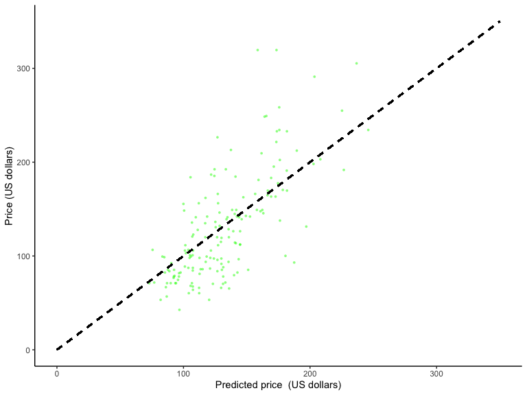